# WAPS Data Cleaning and Validation

This notebook serves as an introductory step in the analysis of WAPS data from 2008-2018, examining the interaction between planted taxa (priority effects) and environmental treatments (watering, fertilization, and clipping) on the maintenance of species diversity and compositional dissimilarity in California grasslands.

## Initial data processing

Loaded files:

- WAPSthrough2017 - Dataframe of composition data (areal estimates of cover by species)
- trtlabels - Dataframe of treatment labels for each plot (planted taxa, treatments, blocking structure)
- WAPSspecies - Dataframe of project species and associated labels/groups

### Data cleaning

There are a bunch of small inconsistencies that come with manual data entry that need to be corrected prior to analysis.

**Checklist:**

- Convert dataset to wide (matrix format) **done**
- Standardize species names **done**
- Clean up year column **done**
- Assign NA cover values to 0 **done**
- Standardize treatment labels **done**
- Add “class” statistics to attribute table **done**

# Error checking:

### What species are present within the dataset:

There seem to be no obvious distinctions among the different groups in this dataset, but need to double-check with Val and David about manual data collection.

Some things to consider:

**Distinctions between labels in the dataset:**

- elymus vs. leymus
- other vs. other.weeds
- thistle vs. unk.thistle vs. milk.thistle vs. italian.thistle
- tarweed vs. any other species?
- bare vs. disturbance

**Specific species IDs**

- What species is mustard?
- What species is oats?
- What species is tarweed?
- What species is trifolium?
- What species is big.leaf.dandelion?

```r
unique(long.comp$species)
```

```
##  [1] "aegilops"               "ag.big"
##  [3] "ag.small"               "amsinckia"
##  [5] "annuals"                "avena"
##  [7] "bare"                   "big.leaf.dandelion"
##  [9] "bindweed"               "bro.carinatus"
## [11] "bro.diandrus"           "bro.hordeaceous"
## [13] "bro.madritensis"        "bunchgrass"
## [15] "cap.bur"                "centaurea"
## [17] "con.arv"                "conyza"
## [19] "dead.grass"             "disturbance"
## [21] "elymus"                 "epilobium.brach"
## [23] "erodium.moschatum"      "galium"
## [25] "geranium"               "grass"
## [27] "gumplant"               "helianthus"
## [29] "hordeum.sp"             "italian.thistle"
```

[output cut: 16 more lines]

### How are cover values distributed? Are there outliers?

Just looking at the disribution of cover values, we see that a number of samples have no live cover (which may be expected), but the distribution is quite right-skewed.

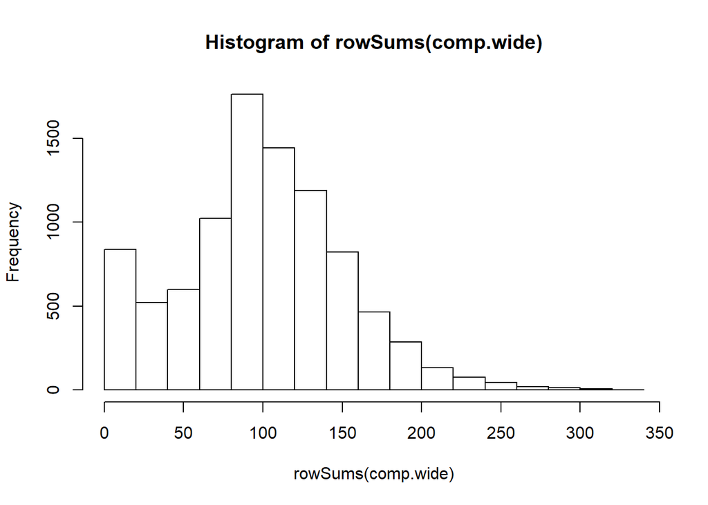

```r
hist(rowSums(comp.wide))
```

**Which plots are responsible for this skewed data?**

Some other values are also really high - why might this be the case? Worth checking with Valerie and David.

```r
wide.comp[order(rowSums(comp.wide), decreasing = TRUE)[1:10],c(1:6, 26:ncol(wide.comp))]
```

|  | plot | block | subblock | water | fertilization | year | avena | bro.hordeaceous | bro.madritensis | bro.diandrus | hordeum.sp | lolium | oats | trifolium | centaurea | bro.carinatus | elymus | leymus | lotus | lupinus | nassella | poa | vulpia | bunchgrass | aegilops | taeniatherum | ag.big | ag.small | amsinckia | … |
| --- | --- | --- | --- | --- | --- | --- | --- | --- | --- | --- | --- | --- | --- | --- | --- | --- | --- | --- | --- | --- | --- | --- | --- | --- | --- | --- | --- | --- | --- | --- |
| 3737 | 340 | 4 | 1 | control | none | 2015 | 25.0 | 0.0 | 0 | 0.0 | 0 | 0 | 0 | 0 | 25 | 0.0 | 0 | 0 | 35 | 2.5 | 0.0 | 0 | 0 | 0 | 2.5 | 35.0 | 0 | 0 | 0 | … |
| 955 | 87 | 1 | 3 | control | none | 2016 | 2.5 | 25.0 | 0 | 0.0 | 0 | 0 | 0 | 95 | 0 | 2.5 | 0 | 65 | 0 | 0.0 | 25.0 | 35 | 0 | 0 | 35.0 | 25.0 | 0 | 0 | 0 | … |
| 536 | 49 | 1 | 2 | control-2nd | high fert | 2015 | 12.5 | 0.0 | 0 | 0.0 | 0 | 0 | 0 | 0 | 0 | 0.0 | 0 | 0 | 0 | 0.0 | 0.0 | 0 | 0 | 0 | 0.0 | 0.0 | 0 | 0 | 0 | … |
| 2835 | 258 | 3 | 2 | control | none | 2015 | 12.5 | 0.0 | 0 | 2.5 | 0 | 0 | 0 | 0 | 0 | 0.0 | 0 | 0 | 0 | 12.5 | 0.0 | 0 | 0 | 0 | 0.0 | 2.5 | 0 | 0 | 0 | … |
| 7873 | 716 | 7 | 3 | control-2nd | none | 2015 | 12.5 | 2.5 | 0 | 0.0 | 0 | 0 | 0 | 85 | 0 | 12.5 | 0 | 0 | 0 | 0.0 | 2.5 | 0 | 0 | 0 | 0.0 | 12.5 | 0 | 0 | 0 | … |
| 250 | 23 | 1 | 1 | latewet | none | 2015 | 0.0 | 12.5 | 0 | 0.0 | 0 | 0 | 0 | 0 | 0 | 0.0 | 0 | 0 | 0 | 25.0 | 0.0 | 0 | 0 | 0 | 0.0 | 0.0 | 0 | 0 | 0 | … |
| 4661 | 424 | 5 | 1 | wet | high fert | 2015 | 12.5 | 12.5 | 0 | 0.0 | 0 | 0 | 0 | 0 | 0 | 0.0 | 0 | 0 | 65 | 0.0 | 0.0 | 0 | 0 | 0 | 12.5 | 25.0 | 0 | 0 | 0 | … |
| 8830 | 803 | 8 | 2 | control-2nd | high fert | 2015 | 55.0 | 12.5 | 0 | 0.0 | 0 | 0 | 0 | 0 | 0 | 2.5 | 0 | 0 | 0 | 2.5 | 75.0 | 0 | 0 | 0 | 0.0 | 25.0 | 0 | 0 | 0 | … |
| 3671 | 334 | 4 | 1 | control | none | 2015 | 65.0 | 0.0 | 0 | 12.5 | 0 | 0 | 0 | 35 | 35 | 0.0 | 0 | 0 | 25 | 12.5 | 0.0 | 0 | 0 | 0 | 0.0 | 55.0 | 0 | 0 | 0 | … |
| 2098 | 191 | 2 | 3 | control | none | 2015 | 25.0 | 0.0 | 0 | 0.0 | 0 | 0 | 0 | 65 | 0 | 0.0 | 0 | 0 | 0 | 12.5 | 0.0 | 0 | 0 | 0 | 12.5 | 2.5 | 0 | 0 | 0 | … |

**Unique cover values**

```r
sort(unique(c(comp.wide)))
```

```
##  [1]  0.00  0.25  0.50  1.50  2.50  3.00  3.50  5.00  8.50 10.00 12.00
## [12] 12.50 12.60 15.00 23.50 24.00 25.00 33.00 35.00 44.00 45.00 55.00
## [23] 65.00 66.00 74.00 75.00 77.00 84.00 85.00 90.00 95.00
```

**Total number of cover values > 100**

```r
sum(c(comp.wide) > 100)
```

```
## [1] 0
```

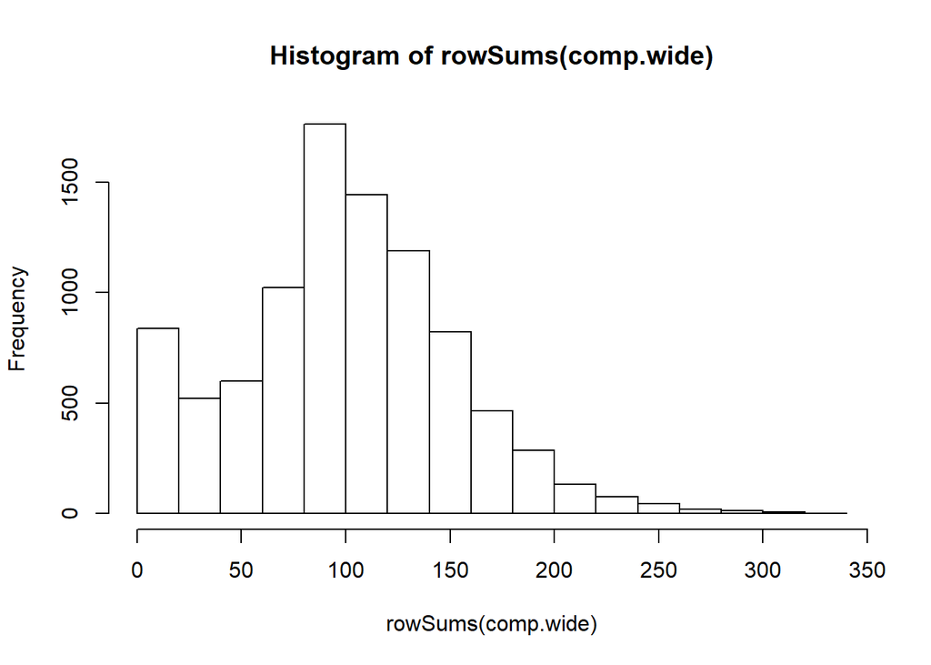

```r
comp.wide[comp.wide == 235] = 23.50
hist(rowSums(comp.wide))
```

```r
wide.comp <- cbind(data.frame(comp.attr), data.frame(comp.wide))
write.csv(x = wide.comp, file = "../data/comdata_wideformat.csv")
```